# Predict activity quality from activity monitors through motion data

Aamarcha

23 août 2014

The exercises were performed by six male participants aged between 20-28 years, with little weight lifting experience. The goal is to predict the activity quality from activity monitors collected from these exercices. Class A corresponds to the specified execution of the exercise, while the other 4 classes correspond to common mistakes. Read more: http://groupware.les.inf.puc-rio.br/har#ixzz3BIcn6MnR

The accuracy of the prediction of the activity quality is arount 99.5% using Random forest algorithm.

# Methodoloy

1. First I clean data : removing NA and not generalized variables, classes as factors.
2. Then I make a partition : 75% for traing data and 25% for test.
3. I build a model using random forest algorithm. GMB implementation takes a very long time.
4. I make predictions basing on this Model.

# Getting Data

Data was downloaded from

1. Training data : https://d396qusza40orc.cloudfront.net/predmachlearn/pml-training.csv
2. Test data : https://d396qusza40orc.cloudfront.net/predmachlearn/pml-testing.csv

The package used for prediction is caret.

```r
library(caret)
library(plyr)
library(randomForest)
library('scales')
```

Reading the data:

```r
trainingMotion <- read.csv("./data/pml-training.csv",stringsAsFactors=F,na.string = c("NA", ""))
testMotion <- read.csv("./data/pml-testing.csv",stringsAsFactors=F,na.string = c("NA", ""))
```

# Cleaning and preparing data

```r
NAcounter  <- apply(trainingMotion, 2, function(x) sum(is.na(x)))
table(round(NAcounter/nrow(trainingMotion), 2))
```

```
##
##    0 0.98
##   60  100
```

```r
trainingMotion  <- trainingMotion[, names(NAcounter)[NAcounter == 0]]
trainingMotion <- trainingMotion[, -c(1:7)]
```

Use classes as a factor.

```r
trainingMotion <- mutate(trainingMotion,classe=factor(classe))
```

```r
set.seed(123)
inTrain <- createDataPartition(y = trainingMotion$classe, p = 0.75, list = F)
trainingMotion.train <- trainingMotion[inTrain, ]
trainingMotion.test <- trainingMotion[-inTrain, ]
```

# Model building

I use the random forest implementation because it’s faster in my context. You can see that the model is 99.5% accurate and the 95% confidence interval for accuracy is from 99.3% to 99.7%.

```r
set.seed(456)
# repeated cross validation
trControl <- trainControl(method="repeatedcv", number=10, repeats=10)

# train with  "rf" method takes a long time
rf.mdl<- randomForest(classe ~ ., data = trainingMotion.train,verbose=FALSE,metric="Accuracy", trControl =trControl )
confusionMatrix <- confusionMatrix(trainingMotion.test$classe, predict(rf.mdl, trainingMotion.test))
confusionMatrix
```

```
## Confusion Matrix and Statistics
##
##           Reference
## Prediction    A    B    C    D    E
##          A 1394    1    0    0    0
##          B    1  947    1    0    0
##          C    0    8  847    0    0
##          D    0    0   10  792    2
##          E    0    0    0    1  900
##
## Overall Statistics
##
##                Accuracy : 0.995
##                  95% CI : (0.993, 0.997)
##     No Information Rate : 0.284
##     P-Value [Acc > NIR] : <2e-16
##
##                   Kappa : 0.994
##  Mcnemar's Test P-Value : NA
##
## Statistics by Class:
##
##                      Class: A Class: B Class: C Class: D Class: E
## Sensitivity             0.999    0.991    0.987    0.999    0.998
## Specificity             1.000    0.999    0.998    0.997    1.000
## Pos Pred Value          0.999    0.998    0.991    0.985    0.999
## Neg Pred Value          1.000    0.998    0.997    1.000    1.000
## Prevalence              0.284    0.195    0.175    0.162    0.184
## Detection Rate          0.284    0.193    0.173    0.162    0.184
## Detection Prevalence    0.284    0.194    0.174    0.164    0.184
## Balanced Accuracy       0.999    0.995    0.993    0.998    0.999
```

Here you have the error plot and the importance of variables in this model.

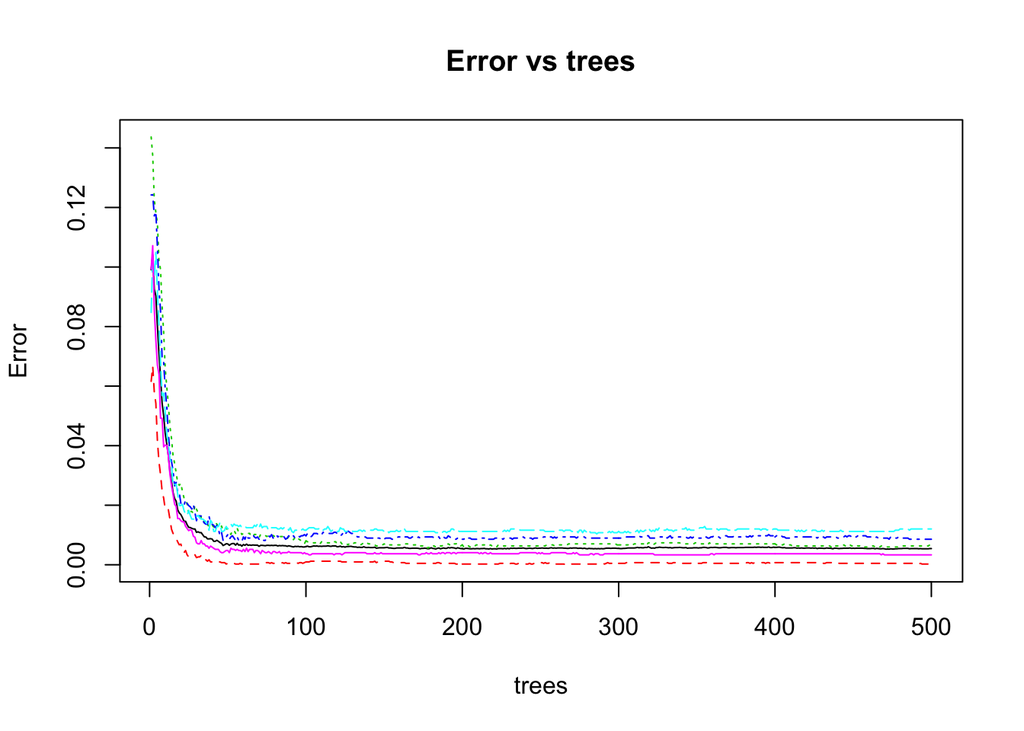

```r
plot(rf.mdl, main="Error vs trees")
```

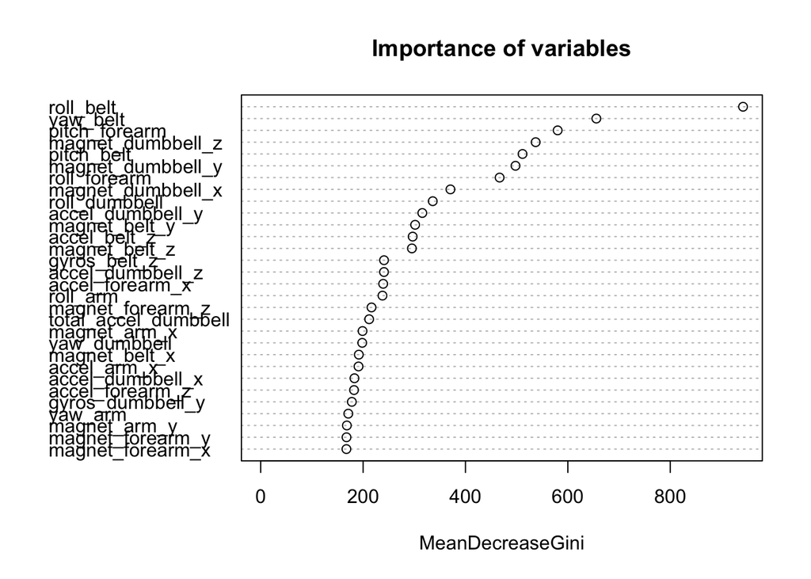

```r
varImpPlot(rf.mdl, main="Importance of variables")
```

Out of sample error rate

```r
percent(1 - confusionMatrix$overall[[1]])
```

```
## [1] "0.489%"
```

# Prediction and submission

```r
pml_write_files = function(x){
  n = length(x)
  for(i in 1:n){
    filename = paste0("problem_id_",i,".txt")
    write.table(x[i],file=filename,quote=FALSE,row.names=FALSE,col.names=FALSE)
  }
}
prediction  <- predict(rf.mdl, testMotion)
prediction
```

```
##  1  2  3  4  5  6  7  8  9 10 11 12 13 14 15 16 17 18 19 20
##  B  A  B  A  A  E  D  B  A  A  B  C  B  A  E  E  A  B  B  B
## Levels: A B C D E
```

```r
pml_write_files(prediction)
```

# Appendix

The importance of variables in this model

```r
importance(rf.mdl)
```

```
##                      MeanDecreaseGini
## roll_belt                      942.23
## pitch_belt                     511.43
## yaw_belt                       655.65
## total_accel_belt               166.59
## gyros_belt_x                    72.99
## gyros_belt_y                    80.79
## gyros_belt_z                   240.88
## accel_belt_x                    88.31
## accel_belt_y                    94.36
## accel_belt_z                   296.84
## magnet_belt_x                  191.64
## magnet_belt_y                  301.66
## magnet_belt_z                  295.36
## roll_arm                       237.86
## pitch_arm                      130.08
## yaw_arm                        171.08
## total_accel_arm                 77.76
## gyros_arm_x                    100.86
## gyros_arm_y                     94.66
## gyros_arm_z                     42.16
## accel_arm_x                    191.06
## accel_arm_y                    121.60
## accel_arm_z                     97.45
## magnet_arm_x                   198.87
## magnet_arm_y                   168.29
## magnet_arm_z                   148.45
## roll_dumbbell                  336.06
## pitch_dumbbell                 132.20
## yaw_dumbbell                   198.30
## total_accel_dumbbell           211.81
## gyros_dumbbell_x                97.60
## gyros_dumbbell_y               178.01
## gyros_dumbbell_z                63.87
## accel_dumbbell_x               183.10
## accel_dumbbell_y               315.67
## accel_dumbbell_z               240.81
## magnet_dumbbell_x              370.61
## magnet_dumbbell_y              497.73
## magnet_dumbbell_z              537.13
## roll_forearm                   466.69
## pitch_forearm                  580.09
## yaw_forearm                    127.70
## total_accel_forearm             83.73
## gyros_forearm_x                 55.43
## gyros_forearm_y                 93.81
## gyros_forearm_z                 64.67
## accel_forearm_x                239.22
## accel_forearm_y                108.27
## accel_forearm_z                182.27
## magnet_forearm_x               167.39
## magnet_forearm_y               167.60
## magnet_forearm_z               216.44
```